# Spatial Clustering: ClustGeo

Maxwell

2022-04-17

https://cran.r-project.org/web/packages/ClustGeo/vignettes/intro_ClustGeo.html

# 1 Preparations

## 1.1 Load libraries

## 1.2 Environment

```r
col.os <- "#414a4c"  # Outer Space
col.rp <- "#7851a9"  # Royal Purple
col.cb <- "#b0b7c6"  # Cadet Blue
col.el <- "#ceff1d"  # Electric Lime
col.rm <- "#e3256b"  # Razzmatazz
col.plos.yellow <- "#D6E13D"  # PLOS ONE
col.plos.pink <- "#CF00A3"  # PLOS ONE
scale.col.1 <- c()
font.1 <- "Candara"
theme_set(theme_minimal(base_family = font.1))
options(dplyr.summarise.inform = TRUE)

t.img <- png::readPNG("fig/twitter.png")
t.grob <- grid::rasterGrob(t.img,
                           width = unit(0.4, "cm"),
                           height = unit(0.4, "cm"),
                           interpolate = FALSE)
```

# 2 Load DataSets

The dataset `estuary` refers to **303 French municipalities of Gironde estuary (a south-ouest French region)**.

- dat: `data.frame` with the description of the 303 municipalities on 4 socio-economic variables.
- D.geo: `matrix` with the distances (303, 303) between the town halls of the 303 municipalities.
- map: `sp::SpatialPolygonsDataFrame` with the map of the municipalities.

```r
data(estuary, package = "ClustGeo")
print(class(estuary))
```

```
## [1] "list"
```

```r
print(names(estuary))
```

```
## [1] "dat"   "D.geo" "map"
```

## 2.1 dat

```r
dat <- estuary$dat
print(dim(dat))
```

```
## [1] 303   4
```

```r
view.table(dat, head.n = 100)
```

|  | employ.rate.city | graduate.rate | housing.appart | agri.land |
| --- | --- | --- | --- | --- |
| 17015 | 28.08 | 17.68 | 5.15 | 90.0443842706944 |
| 17021 | 30.42 | 13.13 | 4.93 | 58.5118165575921 |
| 17030 | 25.42 | 16.28 | 0 | 95.1840434201984 |
| 17034 | 35.08 | 9.06 | 0 | 91.0197494596654 |
| 17050 | 28.23 | 17.13 | 2.51 | 61.7117062009221 |
| 17052 | 22.02 | 12.66 | 3.22 | 61.9079795954791 |
| 17058 | 43.68 | 13.31 | 10.86 | 40.2099595868762 |
| 17060 | 34.67 | 13.29 | 1 | 86.3312694450669 |
| 17064 | 24.36 | 17.3 | 4.16 | 54.0941709833546 |
| 17068 | 48.28 | 10.68 | 4.27 | 70.1002370931763 |

[output cut: 90 more lines]

## 2.2 D.geo

```r
D.geo <- estuary$D.geo
print(dim(D.geo))
```

```
## [1] 303 303
```

## 2.3 map

```r
map <- estuary$map
cat("dim(map):", dim(map), "\n")
```

```
## dim(map): 303 18
```

```r
cat("dim(map@data):", dim(map@data), "\n")
```

```
## dim(map@data): 303 18
```

```r
cat("map@plotOrder[1:10]:", map@plotOrder[1:10], "\n")
```

```
## map@plotOrder[1:10]: 162 165 130 272 254 293 284 111 196 300
```

```r
cat("map@bbox:")
```

```
## map@bbox:
```

```r
print(map@bbox)
```

```
##       min     max
## x  354754  447805
## y 6329392 6537991
```

```r
map.sf <- map %>% st_as_sf()
```

[figure not shown]

```r
ggplot(data = map.sf) +
  geom_sf(fill = col.plos.yellow, color = col.os, alpha = 1) +
  labs(x = NULL, y = NULL,
       title = "303 French municipalities of Gironde estuary") +
  annotation_custom(grob = t.grob,
                    xmin = 420000, xmax = 420000,
                    ymin = 6310000, ymax = 6310000) +
  annotate(geom = "text", x = 433000, y = 6310000,
           label = "@Maxwell_110", size = 3, family = "Candara")
```

```r
ggsave("fig/ClustGeo_01_French-municipalities.jpg", width = 5, height = 10)
```

```r
identical(as.vector(map$INSEE_COM), rownames(dat))
```

```
## [1] TRUE
```

# 3 `hclustgeo`: Hierarchical clustering with soft contiguity constraint

> hclustgeo(D0, D1 = NULL, alpha = 0, scale = TRUE, wt = NULL)

**D0**: class `dist` with the dissimilarities between the n observations. The function as.dist can be used to transform an object of class matrix to object of class dist.

**D1**: class `dist` with other dissimilarities between the same n observations.

**alpha**: value between 0 and 1. This mixing parameter gives the relative importance of D0 compared to D1. By default, this parameter is equal to 0 and D0 is used alone in the clustering process.

**scale**: if TRUE the two dissimilarity matric D0 and D1 are scaled i.e. divided by their max. If D1=NULL, this parameter is not used and D0 is not scaled.

**wt**: vector with the weights of the observations. By default, wt=NULL corresponds to the case where all observations are weighted by 1/n.

## 3.1 w/ D0 only

```r
D0 <- dist(dat)
tree.1 <-
  ClustGeo::hclustgeo(D0 = D0, D1 = NULL, alpha = 0, scale = TRUE, wt = NULL)
```

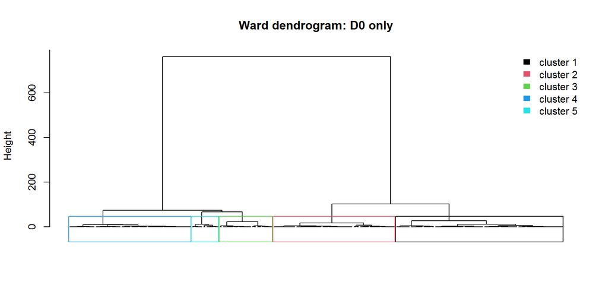

```r
# ?plot.hclust
plot(tree.1, hang = -1, label = FALSE,
     xlab = "", sub = "", main = "Ward dendrogram: D0 only")

rect.hclust(tree.1 , k = 5, border = c(4, 5, 3, 2, 1))
legend("topright", legend = paste("cluster", 1:5),
       fill = 1:5, bty = "n", border = "white")
```

```r
map.sf <- map.sf %>%
  mutate(partition.1 = factor(cutree(tree = tree.1, k = 5),
                              levels = 1:5, labels = 1:5))
```

[figure not shown]

```r
ggplot(data = map.sf) +
  geom_sf(mapping = aes(fill = partition.1),
          color = col.os, alpha = 1, size = 0.25) +
  scale_fill_carto_d(
    palette = "Pastel",
    guide = guide_legend(title = expression("GlustGeo::\n hclustgeo"))
  ) +
  labs(x = NULL, y = NULL,
       title = "303 French municipalities of Gironde estuary:",
       subtitle = "alpha = 0") +
  theme(legend.position = c(0.85, 0.88)) +
  annotation_custom(grob = t.grob,
                    xmin = 420000, xmax = 420000,
                    ymin = 6310000, ymax = 6310000) +
  annotate(geom = "text", x = 434000, y = 6310000,
           label = "@Maxwell_110", size = 3, family = "Candara")
```

```r
ggsave("fig/ClustGeo_01_Partition-1.jpg", width = 5, height = 10)
```

## 3.2 D0 and D1

alpha = 0: only D0 is considered. alpha = 1: only D1 is considered.

Calculate separately the socio-economic homogeneity (denoted Q0) and the geographic homogneity (denoted Q1) of the partitions obtained for a range of alpha and clusters K.  
The homogeneity Q0 (resp. Q1) is the proportion of explained inertia calculated with D0 (resp. D1).

```r
D0 <- dist(dat)
D1 <- dist(x = D.geo)
alpha.seq <- seq(0, 1, 0.1)
K <- 5
cr <- choicealpha(D0, D1, alpha.seq, K,
                  wt = NULL, scale = TRUE, graph = FALSE)
cr$Q # proportion of explained inertia
```

```
##                  Q0        Q1
## alpha=0   0.8134914 0.3985706
## alpha=0.1 0.7550552 0.6031239
## alpha=0.2 0.7577933 0.6534272
## alpha=0.3 0.6840935 0.8097575
## alpha=0.4 0.7108939 0.7771634
## alpha=0.5 0.6921077 0.8164308
## alpha=0.6 0.6868653 0.8187538
## alpha=0.7 0.6514929 0.8365596
## alpha=0.8 0.5402094 0.8773290
## alpha=0.9 0.3540673 0.8913943
## alpha=1   0.4868831 0.8974994
```

```r
crQ.df <- data.frame(cr$Q) %>% mutate(alpha = alpha.seq)
rownames(crQ.df) <- NULL
```

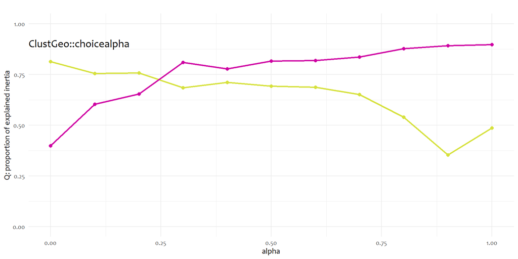

```r
crQ.df %>% ggplot() +
  geom_point(mapping = aes(x = alpha, y = Q0),
             color = col.plos.yellow, size = 2) +
  geom_line(mapping = aes(x = alpha, y = Q0),
            color = col.plos.yellow, size = 1) +
  geom_point(mapping = aes(x = alpha, y = Q1),
             color = col.plos.pink, size = 2) +
  geom_line(mapping = aes(x = alpha, y = Q1),
            color = col.plos.pink, size = 1) +
  lims(y = c(0, 1.)) +
  labs(y = "Q: proportion of explained inertia",
       title = "ClustGeo::choicealpha") +
  theme(plot.title = element_text(
    size = 15,
    margin = margin(t = 50, r = 0, b = -50, l = 0, unit = "pt")
  ))
```

```r
tree.2 <-
  ClustGeo::hclustgeo(D0 = D0, D1 = D1, alpha = 0.2, scale = TRUE, wt = NULL)

map.sf <- map.sf %>%
  mutate(partition.2 = factor(cutree(tree = tree.2, k = 5),
                              levels = 1:5, labels = 1:5))
```

[figure not shown]

```r
ggplot(data = map.sf) +
  geom_sf(mapping = aes(fill = partition.2),
          color = col.os, alpha = 1, size = 0.25) +
  scale_fill_carto_d(
    palette = "Pastel",
    guide = guide_legend(title = expression("GlustGeo::\n hclustgeo"))
  ) +
  labs(x = NULL, y = NULL,
       title = "303 French municipalities of Gironde estuary:",
       subtitle = "alpha = 0.2") +
  theme(legend.position = c(0.85, 0.88)) +
  annotation_custom(grob = t.grob,
                    xmin = 420000, xmax = 420000,
                    ymin = 6310000, ymax = 6310000) +
  annotate(geom = "text", x = 434000, y = 6310000,
           label = "@Maxwell_110", size = 3, family = "Candara")
```

```r
ggsave("fig/ClustGeo_01_Partition-2.jpg", width = 5, height = 10)
```

## 3.3 Another D1

Take the neighborhood between the municipalities into account rather than the geographical distance

```r
list.nb <- poly2nb(map, row.names = rownames(dat))  # also used in `SKATER`
A <- spdep::nb2mat(list.nb, style = "B")
diag(A) <- 1
colnames(A) <- rownames(A) <- as.vector(map$NOM_COMM)
A[1:5, 1:5]
```

```
##          ARCES ARVERT BALANZAC BARZAN BOIS
## ARCES        1      0        0      1    0
## ARVERT       0      1        0      0    0
## BALANZAC     0      0        1      0    0
## BARZAN       1      0        0      1    0
## BOIS         0      0        0      0    1
```

**Note: The dissimilarity matrix D1 is then 1 minus A.**

```r
D0 <- dist(dat)
D1 <- as.dist(1 - A)
alpha.seq <- seq(0, 1, 0.1)
K <- 5
cr <- choicealpha(D0, D1, alpha.seq, K,
                  wt = NULL, scale = TRUE, graph = FALSE)
cr$Q # proportion of explained inertia
```

```
##                  Q0         Q1
## alpha=0   0.8134914 0.04635748
## alpha=0.1 0.7509422 0.05756315
## alpha=0.2 0.7268960 0.06456769
## alpha=0.3 0.6926275 0.06710020
## alpha=0.4 0.6730000 0.06905647
## alpha=0.5 0.6484593 0.07190000
## alpha=0.6 0.6350298 0.07240719
## alpha=0.7 0.5902430 0.07526225
## alpha=0.8 0.5541168 0.07622149
## alpha=0.9 0.5228693 0.07728260
## alpha=1   0.2699756 0.07714010
```

```r
crQ.df <- data.frame(cr$Qnorm) %>% mutate(alpha = alpha.seq)
rownames(crQ.df) <- NULL
```

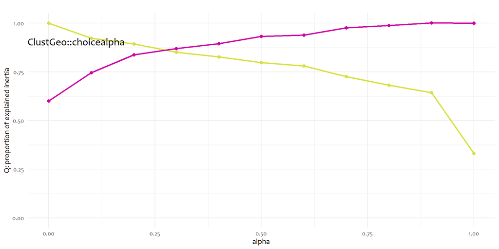

```r
crQ.df %>% ggplot() +
  geom_point(mapping = aes(x = alpha, y = Q0norm),
             color = col.plos.yellow, size = 2) +
  geom_line(mapping = aes(x = alpha, y = Q0norm),
            color = col.plos.yellow, size = 1) +
  geom_point(mapping = aes(x = alpha, y = Q1norm),
             color = col.plos.pink, size = 2) +
  geom_line(mapping = aes(x = alpha, y = Q1norm),
            color = col.plos.pink, size = 1) +
  lims(y = c(0, NA)) +
  labs(y = "Q: proportion of explained inertia",
       title = "ClustGeo::choicealpha") +
  theme(plot.title = element_text(
    size = 15,
    margin = margin(t = 50, r = 0, b = -50, l = 0, unit = "pt")
  ))
```

```r
tree.3 <-
  ClustGeo::hclustgeo(D0 = D0, D1 = D1, alpha = 0.2, scale = TRUE, wt = NULL)

map.sf <- map.sf %>%
  mutate(partition.3 = factor(cutree(tree = tree.3, k = 5),
                              levels = 1:5, labels = 1:5))
```

[figure not shown]

```r
ggplot(data = map.sf) +
  geom_sf(mapping = aes(fill = partition.3),
          color = col.os, alpha = 1, size = 0.25) +
  scale_fill_carto_d(
    palette = "Pastel",
    guide = guide_legend(title = expression("GlustGeo::\n hclustgeo"))
  ) +
  labs(x = NULL, y = NULL,
       title = "303 French municipalities of Gironde estuary:",
       subtitle = "alpha = 0.2; Neighborhood Dissimilarity") +
  theme(legend.position = c(0.85, 0.88)) +
  annotation_custom(grob = t.grob,
                    xmin = 420000, xmax = 420000,
                    ymin = 6310000, ymax = 6310000) +
  annotate(geom = "text", x = 434000, y = 6310000,
           label = "@Maxwell_110", size = 3, family = "Candara")
```

```r
ggsave("fig/ClustGeo_01_Partition-3.jpg", width = 5, height = 10)
```